# Infer ASVs with DADA2

Calla Bush St George

2024-03-05

## Before you start

### Set my seed

```r
# Any number can be chose
set.seed(567890)
```

# Goals for this file

1. Use raw fastq and generate the quality plots to asses the quality of reads
2. Filter and trim out bad sequences and bases from our sequencing files
3. Write out fastq files with high quality sequences
4. Evaluate the quality from our filter and trim.
5. Infer errors on forward and reverse reads individually
6. Identified ASVs on forward and reverse reads separately using the error model.
7. Merge forward and reverse ASVs into “contigous ASVs”.
8. Generate ASV count table. (`otu_table` input for phyloseq.).

# Output that we need:

1. ASV count table: `otu_table`
2. Taxonomy table `tax_table`
3. Sample information: `sample_table` track the reads lost throughout DADA2 workflow.

## Load Libraries

```r
#install.packages("devtools")
library("devtools")
#devtools::install_github("benjjneb/dada2")
library("dada2")
#install.packages("tidyverse")
library("tidyverse")
#install.packages("patchwork")
library("patchwork")
```

## Load Data

```r
#Set the raw fastq path to the raw sequencing files
#Path to the fastq files
raw_fastqs_path <- "data/01_DADA2/01_raw_gzipped_fastqs"

#What files are in this path (Intuition check)
list.files(raw_fastqs_path)
```

```
##  [1] "568_4_S245_L001_R1_001.fastq.gz" "568_4_S245_L001_R2_001.fastq.gz"
##  [3] "568_5_S246_L001_R1_001.fastq.gz" "568_5_S246_L001_R2_001.fastq.gz"
##  [5] "581_5_S247_L001_R1_001.fastq.gz" "581_5_S247_L001_R2_001.fastq.gz"
##  [7] "611_5_S248_L001_R1_001.fastq.gz" "611_5_S248_L001_R2_001.fastq.gz"
##  [9] "E03_5_S146_L001_R1_001.fastq.gz" "E03_5_S146_L001_R2_001.fastq.gz"
## [11] "E05_5_S147_L001_R1_001.fastq.gz" "E05_5_S147_L001_R2_001.fastq.gz"
## [13] "E1_4_S140_L001_R1_001.fastq.gz"  "E1_4_S140_L001_R2_001.fastq.gz"
## [15] "E1_5_S141_L001_R1_001.fastq.gz"  "E1_5_S141_L001_R2_001.fastq.gz"
## [17] "E2_4_S142_L001_R1_001.fastq.gz"  "E2_4_S142_L001_R2_001.fastq.gz"
## [19] "E2_5_S143_L001_R1_001.fastq.gz"  "E2_5_S143_L001_R2_001.fastq.gz"
## [21] "E3_4_S144_L001_R1_001.fastq.gz"  "E3_4_S144_L001_R2_001.fastq.gz"
## [23] "E3_5_S145_L001_R1_001.fastq.gz"  "E3_5_S145_L001_R2_001.fastq.gz"
## [25] "Neg1_S148_L001_R1_001.fastq.gz"  "Neg1_S148_L001_R2_001.fastq.gz"
## [27] "Neg2_S249_L001_R1_001.fastq.gz"  "Neg2_S249_L001_R2_001.fastq.gz"
```

```r
#How many files are there?
str(list.files(raw_fastqs_path))
```

```
##  chr [1:28] "568_4_S245_L001_R1_001.fastq.gz" ...
```

```r
#Create a vector of forward reads
forward_reads <- list.files(raw_fastqs_path, pattern = "_R1_001.fastq.gz", full.names = TRUE)
#Intuition check
head(forward_reads)
```

```
## [1] "data/01_DADA2/01_raw_gzipped_fastqs/568_4_S245_L001_R1_001.fastq.gz"
## [2] "data/01_DADA2/01_raw_gzipped_fastqs/568_5_S246_L001_R1_001.fastq.gz"
## [3] "data/01_DADA2/01_raw_gzipped_fastqs/581_5_S247_L001_R1_001.fastq.gz"
## [4] "data/01_DADA2/01_raw_gzipped_fastqs/611_5_S248_L001_R1_001.fastq.gz"
## [5] "data/01_DADA2/01_raw_gzipped_fastqs/E03_5_S146_L001_R1_001.fastq.gz"
## [6] "data/01_DADA2/01_raw_gzipped_fastqs/E05_5_S147_L001_R1_001.fastq.gz"
```

```r
#Create a vector of reverse reads
reverse_reads <-list.files(raw_fastqs_path, pattern = "_R2_001.fastq.gz",
                           full.names = TRUE)
#Intuition check
head(reverse_reads)
```

```
## [1] "data/01_DADA2/01_raw_gzipped_fastqs/568_4_S245_L001_R2_001.fastq.gz"
## [2] "data/01_DADA2/01_raw_gzipped_fastqs/568_5_S246_L001_R2_001.fastq.gz"
## [3] "data/01_DADA2/01_raw_gzipped_fastqs/581_5_S247_L001_R2_001.fastq.gz"
## [4] "data/01_DADA2/01_raw_gzipped_fastqs/611_5_S248_L001_R2_001.fastq.gz"
## [5] "data/01_DADA2/01_raw_gzipped_fastqs/E03_5_S146_L001_R2_001.fastq.gz"
## [6] "data/01_DADA2/01_raw_gzipped_fastqs/E05_5_S147_L001_R2_001.fastq.gz"
```

```r
#Any duplicates between forward and reverse reads
any(duplicated(c(forward_reads, reverse_reads)))
```

```
## [1] FALSE
```

## Raw Quality plots

```r
#Randomly select 2 samples from dataset to evaluate
random_samples <- sample(1:length(forward_reads), size =2)
random_samples
```

```
## [1] 6 1
```

```r
forward_reads
```

```
##  [1] "data/01_DADA2/01_raw_gzipped_fastqs/568_4_S245_L001_R1_001.fastq.gz"
##  [2] "data/01_DADA2/01_raw_gzipped_fastqs/568_5_S246_L001_R1_001.fastq.gz"
##  [3] "data/01_DADA2/01_raw_gzipped_fastqs/581_5_S247_L001_R1_001.fastq.gz"
##  [4] "data/01_DADA2/01_raw_gzipped_fastqs/611_5_S248_L001_R1_001.fastq.gz"
##  [5] "data/01_DADA2/01_raw_gzipped_fastqs/E03_5_S146_L001_R1_001.fastq.gz"
##  [6] "data/01_DADA2/01_raw_gzipped_fastqs/E05_5_S147_L001_R1_001.fastq.gz"
##  [7] "data/01_DADA2/01_raw_gzipped_fastqs/E1_4_S140_L001_R1_001.fastq.gz"
##  [8] "data/01_DADA2/01_raw_gzipped_fastqs/E1_5_S141_L001_R1_001.fastq.gz"
##  [9] "data/01_DADA2/01_raw_gzipped_fastqs/E2_4_S142_L001_R1_001.fastq.gz"
## [10] "data/01_DADA2/01_raw_gzipped_fastqs/E2_5_S143_L001_R1_001.fastq.gz"
## [11] "data/01_DADA2/01_raw_gzipped_fastqs/E3_4_S144_L001_R1_001.fastq.gz"
## [12] "data/01_DADA2/01_raw_gzipped_fastqs/E3_5_S145_L001_R1_001.fastq.gz"
## [13] "data/01_DADA2/01_raw_gzipped_fastqs/Neg1_S148_L001_R1_001.fastq.gz"
## [14] "data/01_DADA2/01_raw_gzipped_fastqs/Neg2_S249_L001_R1_001.fastq.gz"
```

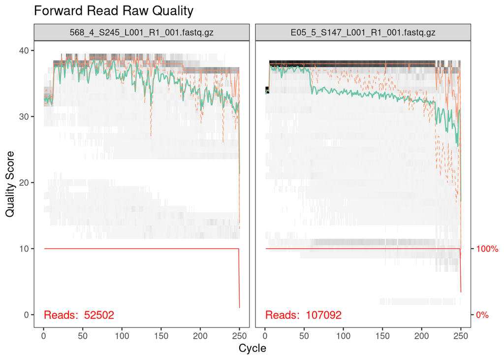

```r
#Calculate and plot quality of these two samples
plotQualityProfile(forward_reads[random_samples]) +
  labs(title = "Forward Read Raw Quality")
```

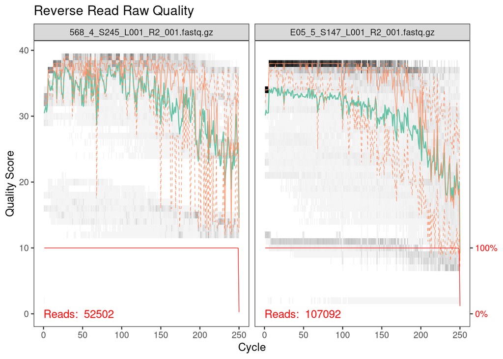

```r
plotQualityProfile(reverse_reads[random_samples]) +
  labs(title = "Reverse Read Raw Quality")
```

## Prepare a placeholder for filtered reads

```r
# vector of our samples, extract the sample information from our file
samples <- sapply(strsplit(basename(forward_reads), "_"), function(x)paste(x[1],x[2],sep="_"))
#Intuition check
head(samples)
```

```
## [1] "568_4" "568_5" "581_5" "611_5" "E03_5" "E05_5"
```

```r
#place filtered reads into filtered_fastqs_path
filtered_fastqs_path <- "data/01_DADA2/02_filtered_fastqs"

# create 2 variables : filtered_F, filtered_R
filtered_forward_reads <- file.path(filtered_fastqs_path, paste0(samples, "_R1_filtered.fastq.gz"))
#Intuition check
head(filtered_forward_reads)
```

```
## [1] "data/01_DADA2/02_filtered_fastqs/568_4_R1_filtered.fastq.gz"
## [2] "data/01_DADA2/02_filtered_fastqs/568_5_R1_filtered.fastq.gz"
## [3] "data/01_DADA2/02_filtered_fastqs/581_5_R1_filtered.fastq.gz"
## [4] "data/01_DADA2/02_filtered_fastqs/611_5_R1_filtered.fastq.gz"
## [5] "data/01_DADA2/02_filtered_fastqs/E03_5_R1_filtered.fastq.gz"
## [6] "data/01_DADA2/02_filtered_fastqs/E05_5_R1_filtered.fastq.gz"
```

```r
length(filtered_forward_reads)
```

```
## [1] 14
```

```r
filtered_reverse_reads <- file.path(filtered_fastqs_path, paste0(samples, "_R2_filtered.fastq.gz"))
#Intuition check
head(filtered_reverse_reads)
```

```
## [1] "data/01_DADA2/02_filtered_fastqs/568_4_R2_filtered.fastq.gz"
## [2] "data/01_DADA2/02_filtered_fastqs/568_5_R2_filtered.fastq.gz"
## [3] "data/01_DADA2/02_filtered_fastqs/581_5_R2_filtered.fastq.gz"
## [4] "data/01_DADA2/02_filtered_fastqs/611_5_R2_filtered.fastq.gz"
## [5] "data/01_DADA2/02_filtered_fastqs/E03_5_R2_filtered.fastq.gz"
## [6] "data/01_DADA2/02_filtered_fastqs/E05_5_R2_filtered.fastq.gz"
```

```r
length(filtered_reverse_reads)
```

```
## [1] 14
```

## Filter and Trim Reads

Parameters of filter and trim **DEPEND ON THE DATASET**

- `maxN` = number of N bases. Remove all Ns from the data.
- `maxEE` = quality filtering threshold applied to expected errors. By default, all expected errors. Mar recommends using c(1,1). Here, if there is maxEE expected errors, its okay. If more, throw away sequence.
- `trimLeft` = trim certain number of base pairs on start of each read
- `truncQ` = truncate reads at the first instance of a quality score less than or equal to selected number. Chose 2
- `rm.phix` = remove phi x
- `compress` = make filtered files .gzipped
- `multithread` = multithread

```r
#Assign a vector to filtered reads
#Trim out poor bases, first three basepairs on forward reads
#Write out filtered fastq files
filtered_reads <-
  filterAndTrim(fwd = forward_reads, filt = filtered_forward_reads,
              rev = reverse_reads, filt.rev = filtered_reverse_reads,
              maxN = 0, maxEE = c(1, 1), trimLeft = 3,
              truncQ = 2, rm.phix = TRUE, compress = TRUE, multithread = TRUE)

#These files are described in Kozich et al 2013 AEM
# Describes library prep
#Forward and reverse read have full overlap
# 515F and 806R
```

### Trimmed Quality Plots

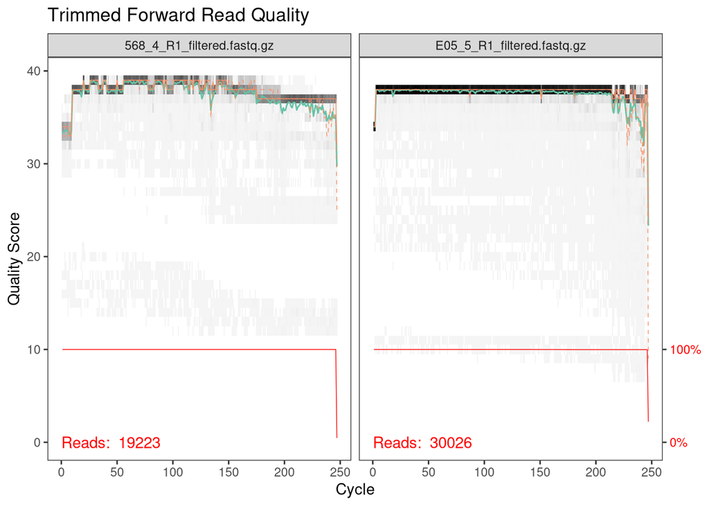

```r
plotQualityProfile(filtered_forward_reads[random_samples]) +
  labs(title = "Trimmed Forward Read Quality")
```

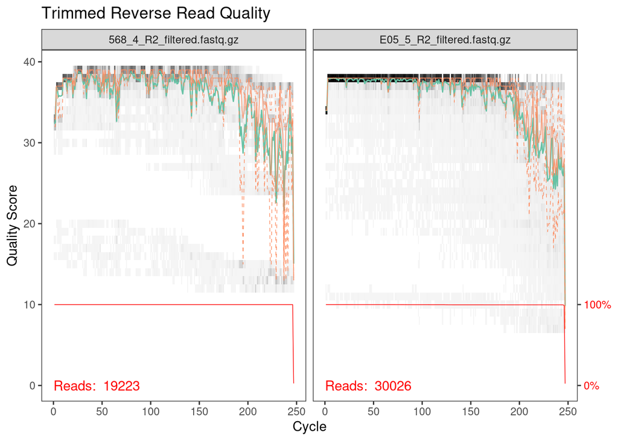

```r
plotQualityProfile(filtered_reverse_reads[random_samples]) +
  labs(title = "Trimmed Reverse Read Quality")
```

## Aggregated Trimmed Plots

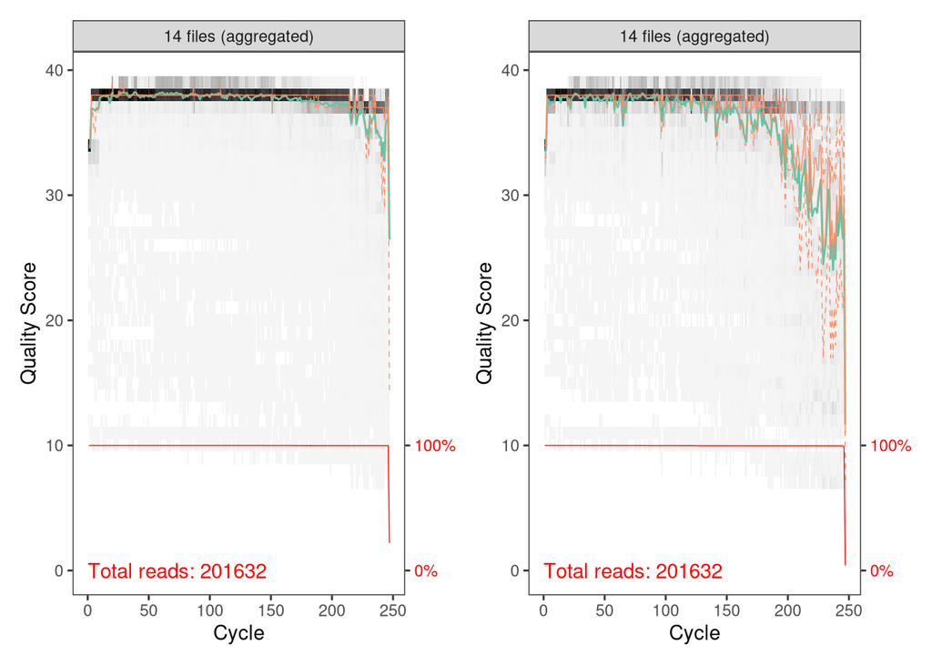

```r
#Aggregrate all QC plots
#Install and library patchwork
plotQualityProfile(filtered_forward_reads, aggregate = TRUE) +
 plotQualityProfile(filtered_reverse_reads, aggregate = TRUE)
```

## Stats on read output from `filterAndTrim`

```r
#Make output into dataframe
filtered_df <- as.data.frame(filtered_reads)
head(filtered_df)
```

```
##                                 reads.in reads.out
## 568_4_S245_L001_R1_001.fastq.gz    52502     19223
## 568_5_S246_L001_R1_001.fastq.gz    38610     12781
## 581_5_S247_L001_R1_001.fastq.gz    35144     11574
## 611_5_S248_L001_R1_001.fastq.gz    30511      9995
## E03_5_S146_L001_R1_001.fastq.gz    16548      5184
## E05_5_S147_L001_R1_001.fastq.gz   107092     30026
```

```r
# calculate some stats
filtered_df %>%
  reframe(median_reads_in = median(reads.in),
          median_reads_out = median(reads.out),
          median_percent_retained = (median(reads.out)/median(reads.in)))
```

```
##   median_reads_in median_reads_out median_percent_retained
## 1           45556            13598               0.2984898
```

## Error Modeling

**NOTE:** Run separtely on each illumina dataset

```r
#Forward reads
error_forward_reads <-
  learnErrors(filtered_forward_reads, multithread = TRUE)
```

```
## 49623653 total bases in 201632 reads from 14 samples will be used for learning the error rates.
```

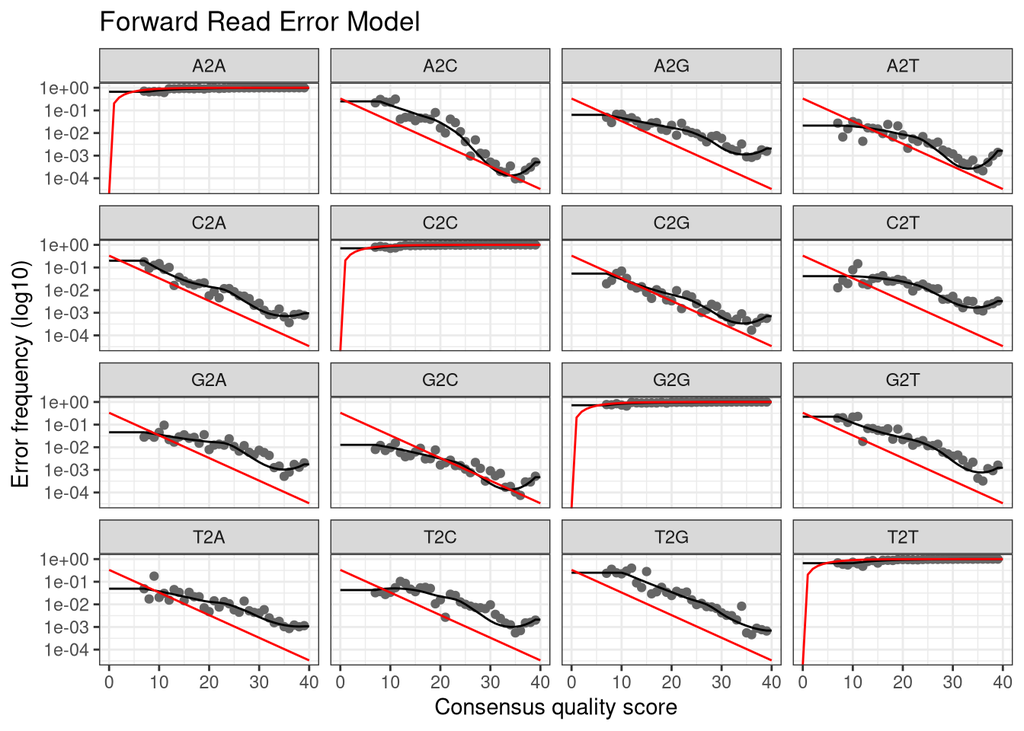

```r
#Plot forward reads errors
plotErrors(error_forward_reads, nominalQ = TRUE) +
  labs(title = "Forward Read Error Model")
```

```r
#Reverse reads
error_reverse_reads <-
  learnErrors(filtered_reverse_reads, multithread = TRUE)
```

```
## 49534367 total bases in 201632 reads from 14 samples will be used for learning the error rates.
```

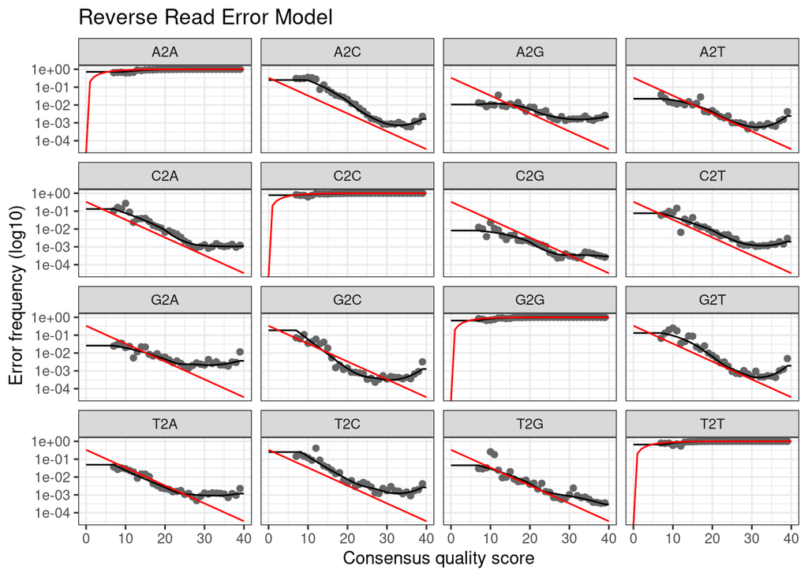

```r
#Plot reverse reads errors
plotErrors(error_reverse_reads, nominalQ = TRUE) +
  labs(title = "Reverse Read Error Model")
```

## Infer ASVs

Note: this is happening separately on the forward and reverse reads. This is unique to DADA2

```r
#Infer forward ASVs
dada_forward <- dada(filtered_forward_reads,
                     err = error_forward_reads, multithread = TRUE)
```

```
## Sample 1 - 19223 reads in 1575 unique sequences.
## Sample 2 - 12781 reads in 2723 unique sequences.
## Sample 3 - 11574 reads in 2589 unique sequences.
## Sample 4 - 9995 reads in 2142 unique sequences.
## Sample 5 - 5184 reads in 1651 unique sequences.
## Sample 6 - 30026 reads in 7339 unique sequences.
## Sample 7 - 27372 reads in 2726 unique sequences.
## Sample 8 - 18099 reads in 4313 unique sequences.
## Sample 9 - 24809 reads in 4461 unique sequences.
## Sample 10 - 23026 reads in 5493 unique sequences.
## Sample 11 - 4933 reads in 1204 unique sequences.
## Sample 12 - 14415 reads in 4519 unique sequences.
## Sample 13 - 23 reads in 18 unique sequences.
## Sample 14 - 172 reads in 124 unique sequences.
```

```r
#Infer reverse ASVs
dada_reverse <- dada(filtered_reverse_reads,
                     err = error_reverse_reads, multithread = TRUE)
```

```
## Sample 1 - 19223 reads in 3101 unique sequences.
## Sample 2 - 12781 reads in 5085 unique sequences.
## Sample 3 - 11574 reads in 4806 unique sequences.
## Sample 4 - 9995 reads in 3996 unique sequences.
## Sample 5 - 5184 reads in 2251 unique sequences.
## Sample 6 - 30026 reads in 10221 unique sequences.
## Sample 7 - 27372 reads in 4382 unique sequences.
## Sample 8 - 18099 reads in 6074 unique sequences.
## Sample 9 - 24809 reads in 6445 unique sequences.
## Sample 10 - 23026 reads in 8077 unique sequences.
## Sample 11 - 4933 reads in 1597 unique sequences.
## Sample 12 - 14415 reads in 6099 unique sequences.
## Sample 13 - 23 reads in 18 unique sequences.
## Sample 14 - 172 reads in 141 unique sequences.
```

#Merge Forward and Reverse ASVs

```r
# merge forward and reverse ASVs
merged_ASVs <- mergePairs(dada_forward, filtered_forward_reads,
                          dada_reverse, filtered_reverse_reads,
                          verbose = TRUE)
```

```
## 17898 paired-reads (in 43 unique pairings) successfully merged out of 19023 (in 58 pairings) input.
```

```
## 11446 paired-reads (in 310 unique pairings) successfully merged out of 12086 (in 403 pairings) input.
```

```
## 10082 paired-reads (in 310 unique pairings) successfully merged out of 10829 (in 415 pairings) input.
```

```
## 8941 paired-reads (in 238 unique pairings) successfully merged out of 9405 (in 315 pairings) input.
```

```
## 4594 paired-reads (in 197 unique pairings) successfully merged out of 4802 (in 250 pairings) input.
```

```
## 28338 paired-reads (in 472 unique pairings) successfully merged out of 29120 (in 589 pairings) input.
```

```
## 26571 paired-reads (in 41 unique pairings) successfully merged out of 27192 (in 64 pairings) input.
```

```
## 17205 paired-reads (in 309 unique pairings) successfully merged out of 17565 (in 376 pairings) input.
```

```
## 23701 paired-reads (in 278 unique pairings) successfully merged out of 24196 (in 356 pairings) input.
```

```
## 22077 paired-reads (in 422 unique pairings) successfully merged out of 22488 (in 519 pairings) input.
```

```
## 4564 paired-reads (in 90 unique pairings) successfully merged out of 4648 (in 110 pairings) input.
```

```
## 13135 paired-reads (in 343 unique pairings) successfully merged out of 13679 (in 449 pairings) input.
```

```
## 9 paired-reads (in 3 unique pairings) successfully merged out of 9 (in 3 pairings) input.
```

```
## 85 paired-reads (in 17 unique pairings) successfully merged out of 85 (in 17 pairings) input.
```

```r
# Evaluate output
typeof(merged_ASVs)
```

```
## [1] "list"
```

```r
length(merged_ASVs)
```

```
## [1] 14
```

```r
names(merged_ASVs)
```

```
##  [1] "568_4_R1_filtered.fastq.gz"     "568_5_R1_filtered.fastq.gz"
##  [3] "581_5_R1_filtered.fastq.gz"     "611_5_R1_filtered.fastq.gz"
##  [5] "E03_5_R1_filtered.fastq.gz"     "E05_5_R1_filtered.fastq.gz"
##  [7] "E1_4_R1_filtered.fastq.gz"      "E1_5_R1_filtered.fastq.gz"
##  [9] "E2_4_R1_filtered.fastq.gz"      "E2_5_R1_filtered.fastq.gz"
## [11] "E3_4_R1_filtered.fastq.gz"      "E3_5_R1_filtered.fastq.gz"
## [13] "Neg1_S148_R1_filtered.fastq.gz" "Neg2_S249_R1_filtered.fastq.gz"
```

## Generate ASV Count Table

```r
# Create ASV count table
raw_ASV_table <- makeSequenceTable(merged_ASVs)

#Write out the file to data/01_DADA2
```